# DATA 624 | Predictive Analytics

Gabriella Martinez

2/19/2022

# Homework 3: Forecasting

## Instructions

Do exercises 5.1, 5.2, 5.3, 5.4 and 5.7 from [Forecasting: Principles and Practice](https://otexts.com/fpp3/) book. Please submit both your Rpubs link as well as attach the .rmd file with your code.

## Packages

```r
library(fpp3)
library(fabletools)
```

**Naive method `NAIVE(y)`:**

- How it works: sets all forecasts to be the value of the last observation
- When to use it / What kind of data to use it on: great on economic and financial time series

**Seasonal naive method `SNAIVE(y)`:**

- How it works: sets each forecast to be equal to the last observed value from the same season (e.g., the same month of the previous year… 02/2019 = 02/2018)
- When to use it / What kind of data to use it on: great on highly seasonal data

**Drift method `RW(y ~ drift())`:**

- How it works: It is a variation on the naïve method. Allows the forecasts to increase or decrease over time, where the amount of change over time (called the drift) is the average change seen historically.
- When to use it / What kind of data to use it on: data with average upward (or downward) trend that is expected to continue in the future [^1]

## Exercises

### 5.1

Produce forecasts for the following series using whichever of `NAIVE(y)`, `SNAIVE(y)` or `RW(y ~ drift())` is more appropriate in each case:

- Australian Population (`global_economy`)
- Bricks (`aus_production`)
- NSW Lambs (`aus_livestock`)
- Household wealth (`hh_budget`)
- Australian takeaway food turnover (`aus_retail`)

**Australian Population** (`global_economy`)

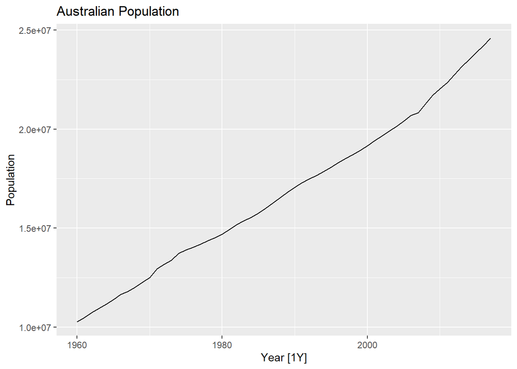

```r
#data prep
aus_pop <- global_economy %>%
  filter(Country == "Australia")
#plot
autoplot(aus_pop, Population)+
  labs(title = "Australian Population")
```

```r
#sum(is.na(aus_pop$Population))
```

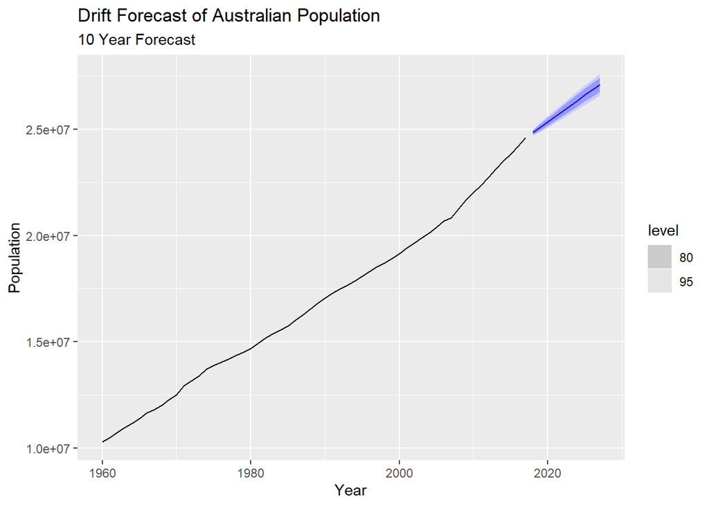

```r
#fit model
aus_pop_fit <- aus_pop %>%
  model(Drift = RW( Population ~ drift()))

#generate forecast
aus_pop_fc = aus_pop_fit %>%
  forecast(h=10)

#plot forecast against actual values
aus_pop_fc %>%
  autoplot(aus_pop) +
  labs(title="Drift Forecast of Australian Population",
       subtitle = "10 Year Forecast",
       xlab="Year", ylab="Population" )
```

`RW(y ~ drift())` was most appropriate for the Australian Population (`global_economy`) data because the data shows an average upward trend that is expected to continue in the future.